# On a way to Chebyshev polynomials as basis functions for the *tfspline* Python module

Version 1.0 Date: 2023-03-07 Contact: hannes.waclawek@fh-salzburg.ac.at

```python
# Imports
import matplotlib.pyplot as plt
import numpy as np
import tensorflow as tf
from tensorflow import keras
from tfspline import model, plot, sampledata
```

## Introduction

The **Jacobi polynomials**  
$P_n^{\alpha,\beta}(x)$  
are a class of polynomials that are orthogonal with respect to the weight function  
$w(x)=(1-x)^\alpha(1+x)^\beta$ on the interval $[-1, 1]$  
and the dot product  
$\int_{a}^{b} p \cdot q\cdot w(x)\,dx$.  
The **Gegenbauer polynomials** are special cases of the Jacobi polynomials, where  
$w(x)=(1-x^2)^{\alpha-\frac{1}{2}}$.  
They include the **Legendre** and **Chebyshev polynomials** as special cases.  
In this notebook, we want to focus on implementing Chebyshev polynomials as a basis for our *tfspline* module.

## (Pre-)Generating Chebyshev polynomials

### Chebyshev basis functions

Let $n \in \mathbb{N_0}$ and $-1 \leq x \leq 1$. The **Chebyshev polynomials of the first kind** are defined via the recurrence relation  
$ T_n(x)= \begin{cases} 1,&\text{if } n = 0\\ x,&\text{if } n = 1\\ 2x\;T_{n-1}(x)-T_{n-2}(x),&\text{else}. \end{cases} $  
At the moment, we are only interested in Chebyshev polynomials of the first kind, as their roots are famously used as nodes (Chebyshev nodes) in polynomial interpolation to minimize the problem of Runge's phenomenon. We want to verify if these favorable properties for interpolation also generalize to our approximation setting with TensorFlow optimizers. The Chebyshev polynomials $T_0, T_1, \dots, T_n$ form a basis of the vector space of polynomials up to $n$ over $\mathbb{R}$, for all $n \in \mathbb{N_0}$, over the interval $[-1, 1]$. This implies that the $n+1$ Chebyshev polynomials are linearly independent for all $n \in \mathbb{N_0}$.

```python
spline = model.Spline(polydegree=5, polynum=1, ck=2, basis='chebyshev')
x_arr = np.linspace(-1, 1, 100)
```

In the *tfspline* module, we implement the definition above in the *_generate_chebyshev_polynomial()* function. If we pass the *poly1d* polynomial/monomial $x$ to that function...

```python
p = np.poly1d([0, 1, 0])
print(p)
```

```
1 x
```

... for $n$, we receive the corresponding Chebyshev polynomial $T_n$.

```python
n = 2
pp1 = spline._generate_chebyshev_polynomial(n,p,0)
pp2 = spline._generate_chebyshev_polynomial(n,p,-0.1)
print(pp1)
print(pp2)
```

```
   2
2 x - 1
   2
2 x + 0.4 x - 0.98
```

$2x^2-1$ equals the Chebyshev polynomial of first kind $T_2(x) = 2x^2-1$. Let's generate some more:

```python
# passing p onto evaluate function generates Chebyshev polynomials
for i in range(5):
    print(spline._generate_chebyshev_polynomial(i,p,0))
```

```
[1]

1 x
   2
2 x - 1
   3
4 x - 3 x
   4     2
8 x - 8 x + 1
```

Horizontally moving the polynomial by $x_0 = -0.1$ also works, as this plot shows:

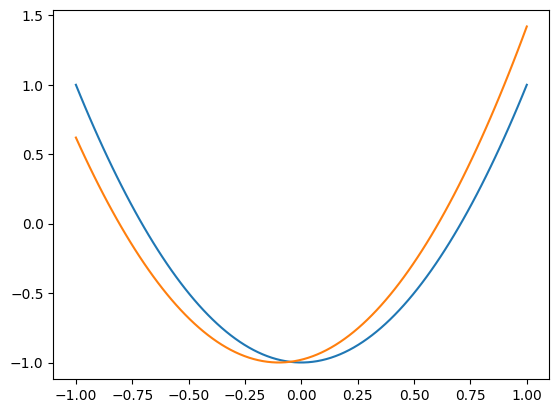

```python
plt.plot(x_arr, pp1(x_arr))
plt.plot(x_arr, pp2(x_arr))
```

Let's plot the first Chebyshev polynomials...

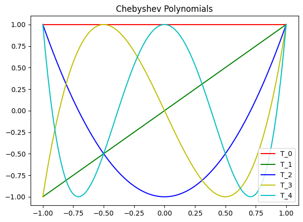

```python
# Print first 5 Chebyshev Polynomials
fig, ax = plt.subplots()
fig.set_figwidth(7)
fig.set_figheight(5)

ax.set_title('Chebyshev Polynomials')

colors = ['r', 'g', 'b', 'y', 'c', 'm']
k = 0

for i in range(0,5):
    if k >= (len(colors)):
        k = 0
    y = spline._generate_chebyshev_polynomial(i,x_arr,0)
    #y = spline._evaluate_horner([1,1,1,1,1,1], x_arr, 0)
    ax.plot(x_arr, y, colors[k], label=f'T_{i}')

    k+=1

ax.legend()
```

... they seem to be generated correctly!

## Shifted Chebyshev polynomials

The Chebyshev polynomials $T_0, T_1, \dots, T_n$ form a basis of the vector space of polynomials up to $n$ over $\mathbb{R}$, for all $n \in \mathbb{N_0}$, over the interval $[-1, 1]$. Our existing *tfspline* implementation works in the range $[0,1]$. Generelly, performing analytical and numerical work, it is often more convenient to use the half interval $[0, 1]$ instead of the full interval $[-1, 1]$. Applying an affine transformation, we can change validity of the Chebyshev basis to the range $[0,1]$. This is done by multiplying the shifting function $(2x -1)$ with the Chebyshev polynomial $T_n$  
$ T*_n(x) = T_n(2x -1), $  
with starting values  
$ T*_0(x) = 1\\ T*_1(x) = 2x-1. $  
The recurrence relation is adapted to  
$ T^*_n(x)= \begin{cases} 1,&\text{if } n = 0\\ 2x-1,&\text{if } n = 1\\ 2(2x-1)\;T^*_{n-1}(x)-T^*_{n-2}(x),&\text{else}. \end{cases} $  
The shifted Chebyshev polynomials of the first kind are orthogonal on the support interval [0,1] with respect to the weight function $w(x)=\frac{1}{x-x^2}$ and normalized by the requirement that $T^*_n(1) = 1$. For the first four Chebyshev polynomials of the first kind, this leaves us with  
$ T^*_0(x) = 1\\ T^*_1(x) = 2x-1\\ T^*_2(x) = 8x^2-8x+1\\ T^*_3(x) = 32x^3-48x^2+18x-1. $

In the *tfspline* module, we implement the definition above in the *_generate_shifted_chebyshev_polynomial()* function. If we pass the *poly1d* polynomial/monomial $x$ to that function...

```python
# passing p onto evaluate function generates Chebyshev polynomials
for i in range(5):
    print(spline._generate_shifted_chebyshev_polynomial(i,p,0))
```

```
[1]

2 x - 1
   2
8 x - 8 x + 1
    3      2
32 x - 48 x + 18 x - 1
     4       3       2
128 x - 256 x + 160 x - 32 x + 1
```

... for $n$, we receive the corresponding Chebyshev polynomial $T_n$. Let's now look at a plot of the first shifted Chebyshev polynomials.

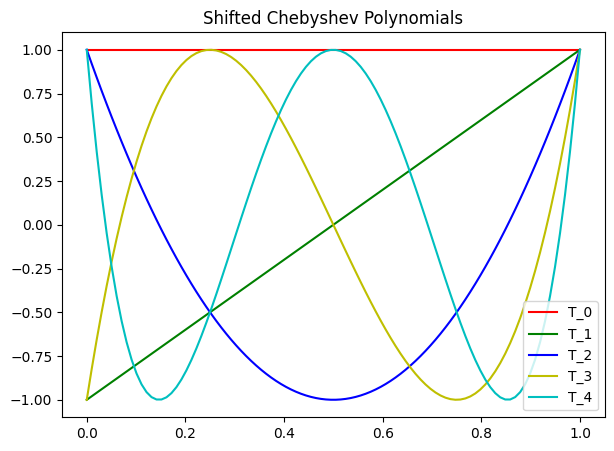

```python
# Plot first 5 shifted Chebyshev Polynomials
spline = model.Spline(polydegree=5, polynum=1, ck=2, basis='shifted_chebyshev')
x_arr = np.linspace(0, 1, 100)

fig, ax = plt.subplots()
fig.set_figwidth(7)
fig.set_figheight(5)

ax.set_title('Shifted Chebyshev Polynomials')

colors = ['r', 'g', 'b', 'y', 'c', 'm']
k = 0

for i in range(0,5):
    if k >= (len(colors)):
        k = 0
    y = spline._generate_shifted_chebyshev_polynomial(i,x_arr,0)
    #y = spline._evaluate_horner([1,1,1,1,1,1], x_arr, 0)
    ax.plot(x_arr, y, colors[k], label=f'T_{i}')

    k+=1

ax.legend()
```

... they seem to be generated correctly!

## Chebyshev expansion / series

Let $a_i \in \mathbb{R}$. Then the Chebyshev expansion / Chebyshev series  
$ \sum_{i=0}^{n}a_i\;T_i(x) $  
evaluates to a polynomial of degree $n$.  
Example:  
Let $a_i = (1, 2, 3)$, then  
$ p(x) = 1 \cdot 1 + 2 \cdot x + 3 \cdot (2x \cdot x - 1) \\ = 6x^2 + 2x - 2. $

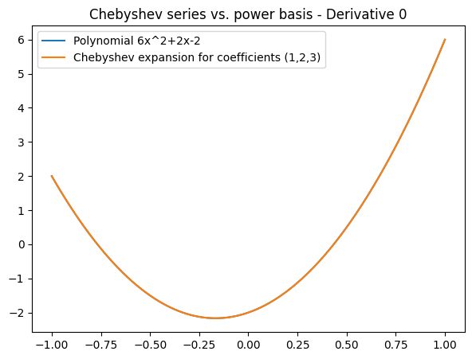

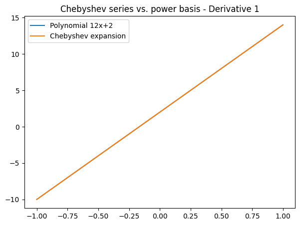

```python
spline = model.Spline(polydegree=2, polynum=1, basis='chebyshev', ck=0, shift_polynomial_centers='mean')
x_arr = np.linspace(-1, 1, 100)
spline.polynum = 1
spline.initialize_l2fit = False
spline.data_x = x_arr
spline._split_data(overlap=0)
spline._get_boundary_points_uniform()

# Chebyshev expansion
ai=[1, 2, 3]
spline.coeffs[0] = tf.Variable(ai, dtype='float64', trainable=True)

# compare to 6x^2+2x-2
y = spline.evaluate_spline_at_x(x_arr, deriv=0)

fig, ax = plt.subplots()
fig.set_figwidth(7)
fig.set_figheight(5)
ax.plot(x_arr, np.polyval([6, 2, -2], x_arr), label='Polynomial 6x^2+2x-2')
ax.plot(x_arr, y, label='Chebyshev expansion for coefficients (1,2,3)')
ax.set_title('Chebyshev series vs. power basis - Derivative 0')
ax.legend()


# compare to 12x+2
y_1 = spline.evaluate_spline_at_x(x_arr, deriv=1)

fig, ax = plt.subplots()
fig.set_figwidth(7)
fig.set_figheight(5)
ax.plot(x_arr, np.polyval([0, 12, 2], x_arr), label='Polynomial 12x+2')
ax.plot(x_arr, y_1, label='Chebyshev expansion')
ax.set_title('Chebyshev series vs. power basis - Derivative 1')
ax.legend()
```

This is also the case for shifted Chebyshev polynomials.  
Example:  
Let $a_i = (1, 2, 3)$, then  
$ p(x) = 1 \cdot 1 + 2 (2x-1) + 3 (8x^2 - 8x +1) \\ = 24x^2-20x+2. $

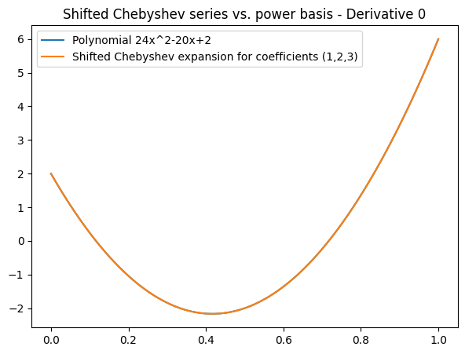

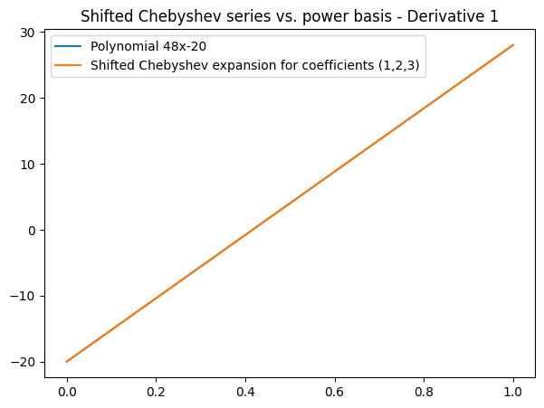

```python
spline = model.Spline(polydegree=2, polynum=1, basis='shifted_chebyshev', ck=0, shift_polynomial_centers='boundary')
x_arr = np.linspace(0, 1, 100)
spline.polynum = 1
spline.initialize_l2fit = False
spline.data_x = x_arr
spline._split_data(overlap=0)
spline._get_boundary_points_uniform()

# Chebyshev expansion
ai=[1, 2, 3]
spline.coeffs[0] = tf.Variable(ai, dtype='float64', trainable=True)
y = spline.evaluate_spline_at_x(x_arr, deriv=0)

# compare to 24x^2-20x+2
fig, ax = plt.subplots()
fig.set_figwidth(7)
fig.set_figheight(5)
ax.plot(x_arr, np.polyval([24, -20, 2], x_arr), label='Polynomial 24x^2-20x+2')
ax.plot(x_arr, y, label='Shifted Chebyshev expansion for coefficients (1,2,3)')
ax.set_title('Shifted Chebyshev series vs. power basis - Derivative 0')
ax.legend()

y1 = spline.evaluate_spline_at_x(x_arr, deriv=1)

# compare to 48x-20
fig, ax = plt.subplots()
fig.set_figwidth(7)
fig.set_figheight(5)
ax.plot(x_arr, np.polyval([0, 48, -20], x_arr), label='Polynomial 48x-20')
ax.plot(x_arr, y1, label='Shifted Chebyshev expansion for coefficients (1,2,3)')
ax.set_title('Shifted Chebyshev series vs. power basis - Derivative 1')
ax.legend()
```

### Attention

Shifting polynomial centers to the mean of the interval does affect the result here, while it does not for "vanilla" Chebyshev, since the center of the interval is no longer 0.

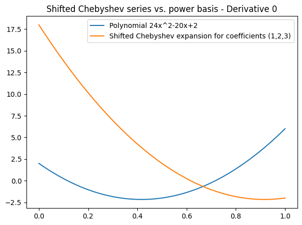

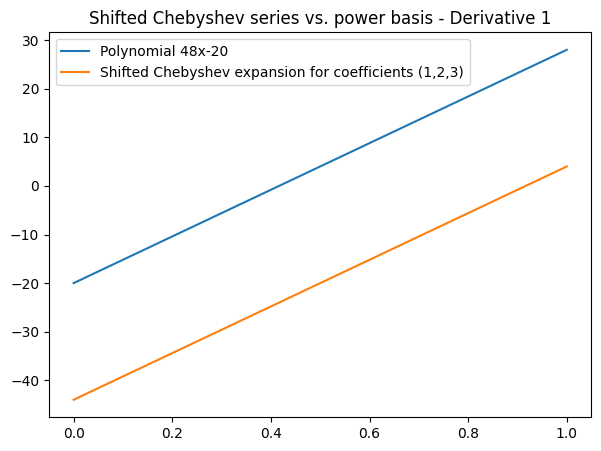

```python
spline = model.Spline(polydegree=2, polynum=1, basis='shifted_chebyshev', ck=0, shift_polynomial_centers='mean')
x_arr = np.linspace(0, 1, 100)
spline.polynum = 1
spline.initialize_l2fit = False
spline.data_x = x_arr
spline._split_data(overlap=0)
spline._get_boundary_points_uniform()

# Chebyshev expansion
ai=[1, 2, 3]
spline.coeffs[0] = tf.Variable(ai, dtype='float64', trainable=True)
y = spline.evaluate_spline_at_x(x_arr, deriv=0)

# compare to 24x^2-20x+2
fig, ax = plt.subplots()
fig.set_figwidth(7)
fig.set_figheight(5)
ax.plot(x_arr, np.polyval([24, -20, 2], x_arr), label='Polynomial 24x^2-20x+2')
ax.plot(x_arr, y, label='Shifted Chebyshev expansion for coefficients (1,2,3)')
ax.set_title('Shifted Chebyshev series vs. power basis - Derivative 0')
ax.legend()

y1 = spline.evaluate_spline_at_x(x_arr, deriv=1)

# compare to 48x-20
fig, ax = plt.subplots()
fig.set_figwidth(7)
fig.set_figheight(5)
ax.plot(x_arr, np.polyval([0, 48, -20], x_arr), label='Polynomial 48x-20')
ax.plot(x_arr, y1, label='Shifted Chebyshev expansion for coefficients (1,2,3)')
ax.set_title('Shifted Chebyshev series vs. power basis - Derivative 1')
ax.legend()
```

## Derivatives of Chebyshev series

Using the monomial $x$ in poly1d form, with our _evaluate_chebyshev() function, we can generate all needed Chebyshev polynomials and store them for later use We can now extend this principle to pre-generate derivatives for all non-zero (according to degree parameter) derivatives. The highest possible derivative number, for which the function will not be 0, is $n$. e.g. $f(x) = 16 x^5 -20x^3+5x, n=5$ $f^{(5)}(x) = 16 \cdot 5 \cdot 4 \cdot 3 \cdot 2 \cdot 1$ We create derivatives for polynomials with monomial base by modifying coefficients like $[a, b, c, d, …]$ to $[b, 2c, 3d, …]$.

We now have a Chebyshev Series in the form $f(x)=\sum_{i=0}^{n}a_i \cdot T_i(x),$ where $a_i$ are the TensorFlow variables to optimize.

Since we now have all relevant Chebyshev polynomial derivatives $T_i^{(d)}$, we can formulate the derivative as $f^{(d)}(x)=\sum_{i=0}^{n}a_i \cdot T_i^{(d)}(x).$

This allows us to pre-generate relevant Chebyshev derivatives in the beginning of the training loop and re-use them.

## Test *tfspline* public functions

### Spline properties

```python
# Spline config
n_segments = 4
degree = 3
ck = 0
```

```python
# Optimization config
learning_rate = 0.1
epochs = 500
lambd = 1
gradient_regularization=True
```

### Generate input data and rescale axes

The input space needs to be rescaled such that every polynomial segment is in the range `[0, 1]`. This allows for same optimization conditions for all segments. See paper for details.

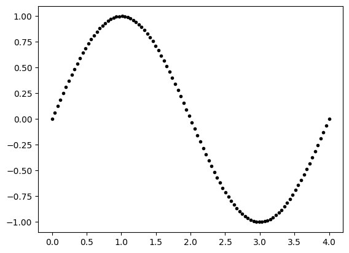

```python
[data_x, data_y] = sampledata.generate_sample_data_sin(n=100, f=1, noise_factor=0)
data_x = sampledata.rescale_input_data(data_x, n_segments)

# Plot data
plt.plot(data_x, data_y, 'k.')
```

### Fit spline to data

and plot result.

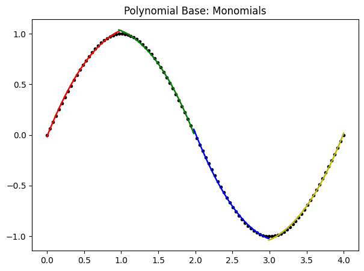

```python
spline_monomial = model.Spline(polydegree=degree, polynum=n_segments, ck=ck, shift_polynomial_centers='mean')
spline_monomial.continuity = False
opt_sgd = keras.optimizers.SGD(learning_rate=learning_rate, momentum=0.95, nesterov=True)

spline_monomial.fit(data_x, data_y, optimizer=opt_sgd, n_epochs=epochs, factor_approximation_quality=lambd,
factor_ck_pressure=1-lambd, initialize_l2fit=False)

plot.plot_spline(spline_monomial, title='Polynomial Base: Monomials')
```

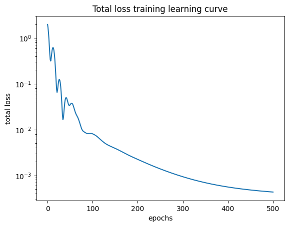

```python
plot.plot_loss(spline_monomial, 'total')
```

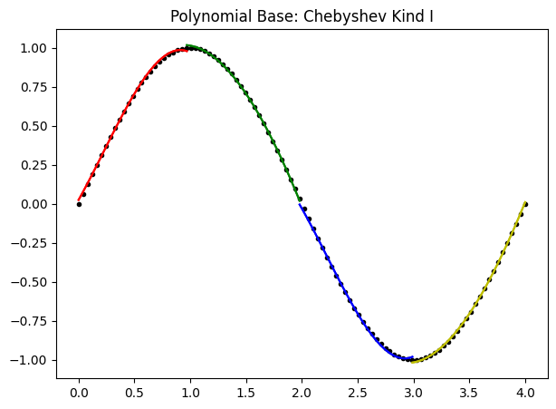

```python
spline_chebyshev = model.Spline(polydegree=degree, polynum=n_segments, ck=ck, basis='chebyshev', shift_polynomial_centers='boundary')
spline_chebyshev.continuity = False
opt_sgd = keras.optimizers.SGD(learning_rate=learning_rate, momentum=0.95, nesterov=True)

spline_chebyshev.fit(data_x, data_y, optimizer=opt_sgd, n_epochs=epochs, factor_approximation_quality=lambd,
factor_ck_pressure=1-lambd, initialize_l2fit=False)

plot.plot_spline(spline_chebyshev, title='Polynomial Base: Chebyshev Kind I')
```

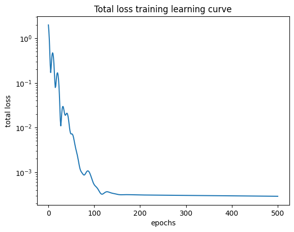

```python
plot.plot_loss(spline_chebyshev, 'total')
```

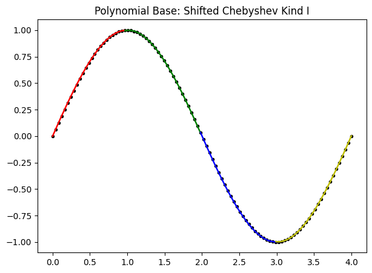

```python
spline_shifted_chebyshev = model.Spline(polydegree=degree, polynum=n_segments, ck=ck, basis='shifted_chebyshev', shift_polynomial_centers='boundary')
spline_shifted_chebyshev.continuity = False
opt_sgd = keras.optimizers.SGD(learning_rate=learning_rate, momentum=0.95, nesterov=True)

spline_shifted_chebyshev.fit(data_x, data_y, optimizer=opt_sgd, n_epochs=epochs, factor_approximation_quality=lambd,
factor_ck_pressure=1-lambd, initialize_l2fit=False)

plot.plot_spline(spline_shifted_chebyshev, title='Polynomial Base: Shifted Chebyshev Kind I')
```

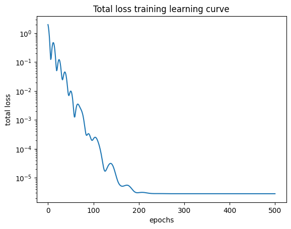

```python
plot.plot_loss(spline_shifted_chebyshev, 'total')
```

### Discussion

The best results are achieved with shifted Chebyshev polynomials as a basis. shift_polynomial_centers='boundary' is very important, as fitting does not converge without shifting.

## Test derivative implementation

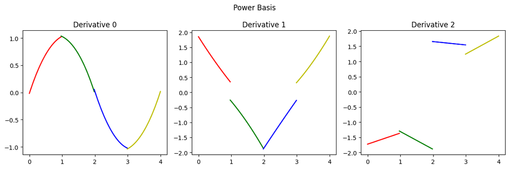

```python
fig, axes = plt.subplots(1, 3, figsize=(12, 4))
fig.suptitle('Power Basis')

# You can now customize each axis as needed
plot.plot_spline(spline_monomial, plot_input=False, deriv=0, ax=axes[0])
axes[0].set_title('Derivative 0')
plot.plot_spline(spline_monomial, plot_input=False, deriv=1, ax=axes[1])
axes[1].set_title('Derivative 1')
plot.plot_spline(spline_monomial, plot_input=False, deriv=2, ax=axes[2])
axes[2].set_title('Derivative 2')

# Adjust layout to prevent overlapping labels and titles
plt.tight_layout()

# Show the plot
plt.show()
```

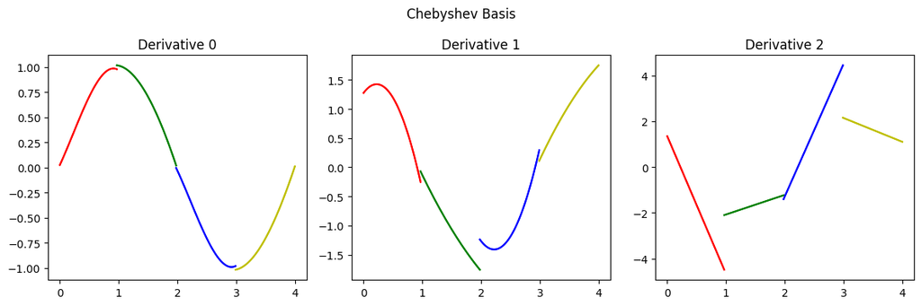

```python
fig, axes = plt.subplots(1, 3, figsize=(12, 4))
fig.suptitle('Chebyshev Basis')

# You can now customize each axis as needed
plot.plot_spline(spline_chebyshev, plot_input=False, deriv=0, ax=axes[0])
axes[0].set_title('Derivative 0')
plot.plot_spline(spline_chebyshev, plot_input=False, deriv=1, ax=axes[1])
axes[1].set_title('Derivative 1')
plot.plot_spline(spline_chebyshev, plot_input=False, deriv=2, ax=axes[2])
axes[2].set_title('Derivative 2')

# Adjust layout to prevent overlapping labels and titles
plt.tight_layout()

# Show the plot
plt.show()
```

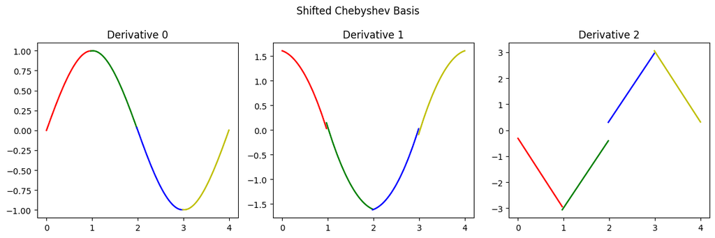

```python
fig, axes = plt.subplots(1, 3, figsize=(12, 4))
fig.suptitle('Shifted Chebyshev Basis')

# You can now customize each axis as needed
plot.plot_spline(spline_shifted_chebyshev, plot_input=False, deriv=0, ax=axes[0])
axes[0].set_title('Derivative 0')
plot.plot_spline(spline_shifted_chebyshev, plot_input=False, deriv=1, ax=axes[1])
axes[1].set_title('Derivative 1')
plot.plot_spline(spline_shifted_chebyshev, plot_input=False, deriv=2, ax=axes[2])
axes[2].set_title('Derivative 2')

# Adjust layout to prevent overlapping labels and titles
plt.tight_layout()

# Show the plot
plt.show()
```

## Test Ck-loss optimiziation

### Degree 3 polynomials, C^1-continuity

```python
lambd = 0.5
ck=1
degree=3
```

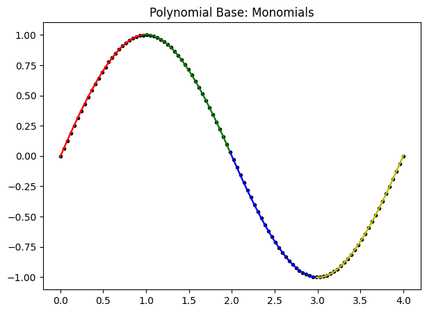

```python
spline_monomial = model.Spline(polydegree=degree, polynum=n_segments, ck=ck)
spline_monomial.continuity = False
opt_sgd = keras.optimizers.SGD(learning_rate=learning_rate, momentum=0.95, nesterov=True)
opt_ams = keras.optimizers.Adam(learning_rate=learning_rate, amsgrad=True)

spline_monomial.fit(data_x, data_y, optimizer=opt_ams, n_epochs=epochs, factor_approximation_quality=lambd,
factor_ck_pressure=1-lambd, initialize_l2fit=False)

plot.plot_spline(spline_monomial, title='Polynomial Base: Monomials')
```

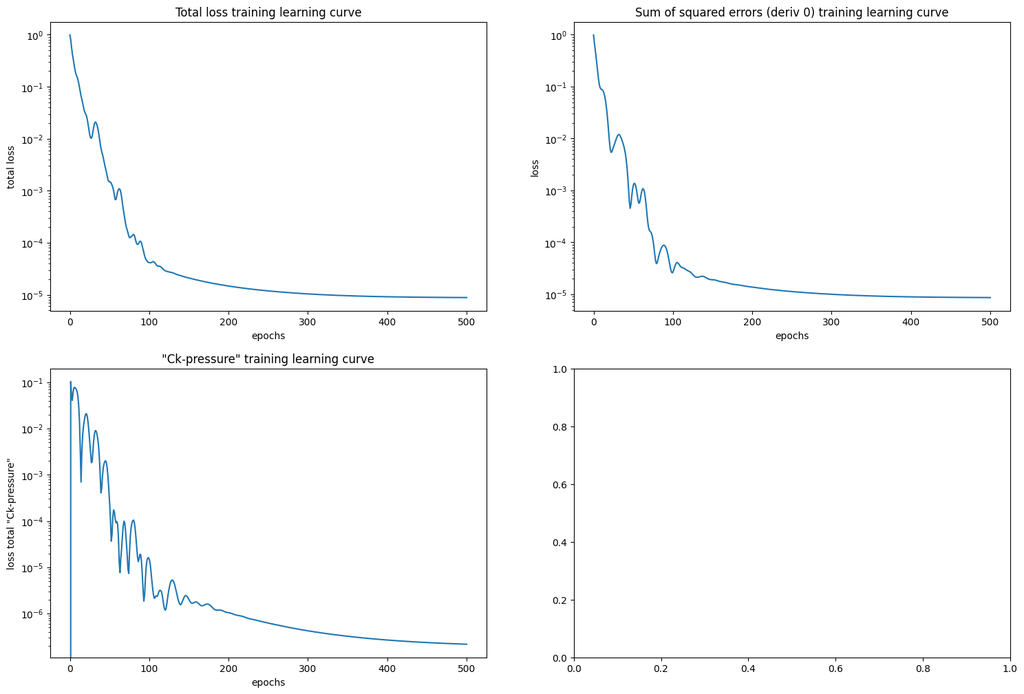

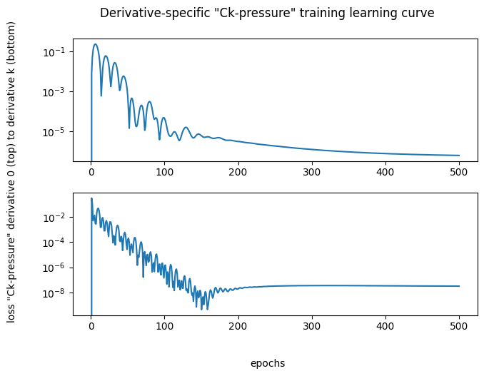

```python
fig, axes = plt.subplots(2, 2, figsize=(18, 12))

# You can now customize each axis as needed
plot.plot_loss(spline_monomial, 'total', ax=axes[0][0])
plot.plot_loss(spline_monomial, 'approx', ax=axes[0][1])
plot.plot_loss(spline_monomial, 'ck-D', ax=axes[1][0])
plot.plot_loss(spline_monomial, 'ck-d', ax=axes[1][1])

# Show the plot
plt.show()
```

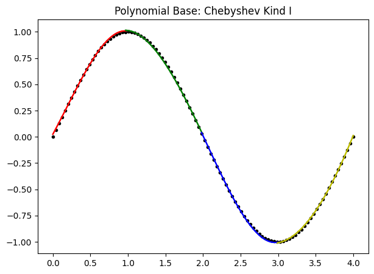

```python
spline_chebyshev = model.Spline(polydegree=degree, polynum=n_segments, ck=ck, basis='chebyshev', shift_polynomial_centers='boundary')
spline_chebyshev.continuity = False
opt_sgd = keras.optimizers.SGD(learning_rate=learning_rate, momentum=0.95, nesterov=True)
opt_ams = keras.optimizers.Adam(learning_rate=learning_rate, amsgrad=True)

spline_chebyshev.fit(data_x, data_y, optimizer=opt_ams, n_epochs=epochs, factor_approximation_quality=lambd,
factor_ck_pressure=1-lambd, initialize_l2fit=False)

plot.plot_spline(spline_chebyshev, title='Polynomial Base: Chebyshev Kind I')
```

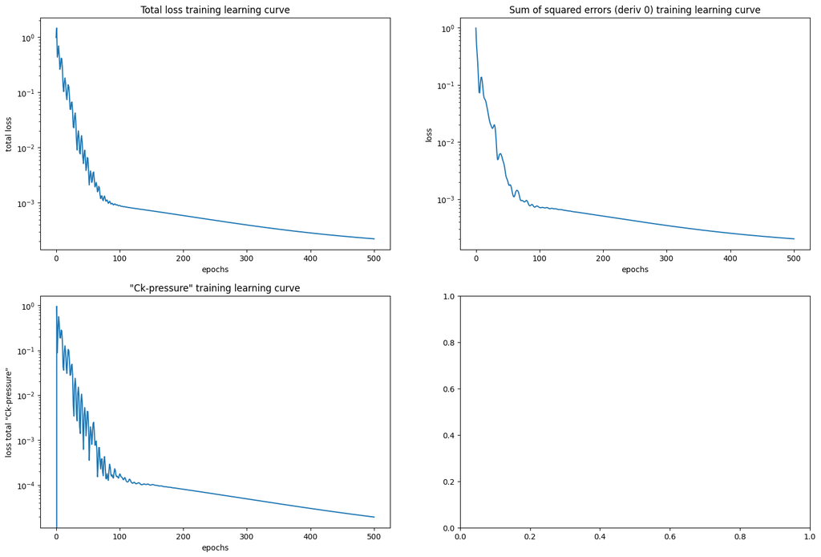

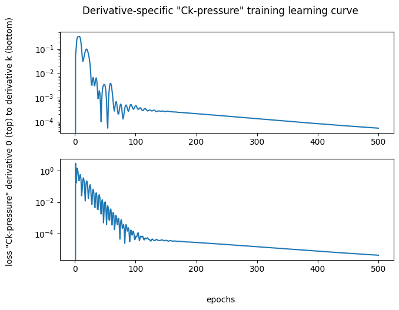

```python
fig, axes = plt.subplots(2, 2, figsize=(18, 12))

# You can now customize each axis as needed
plot.plot_loss(spline_chebyshev, 'total', ax=axes[0][0])
plot.plot_loss(spline_chebyshev, 'approx', ax=axes[0][1])
plot.plot_loss(spline_chebyshev, 'ck-D', ax=axes[1][0])
plot.plot_loss(spline_chebyshev, 'ck-d', ax=axes[1][1])

# Show the plot
plt.show()
```

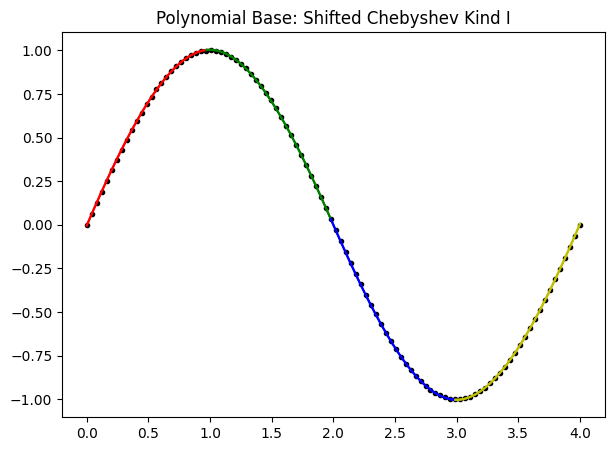

```python
lambd=0.5
spline_shifted_chebyshev = model.Spline(polydegree=degree, polynum=n_segments, ck=ck, basis='shifted_chebyshev', shift_polynomial_centers='boundary')
spline_shifted_chebyshev.continuity = False
opt_sgd = keras.optimizers.SGD(learning_rate=learning_rate, momentum=0.95, nesterov=True)
opt_ams = keras.optimizers.Adam(learning_rate=learning_rate, amsgrad=True)

spline_shifted_chebyshev.fit(data_x, data_y, optimizer=opt_ams, n_epochs=epochs, factor_approximation_quality=lambd,
factor_ck_pressure=1-lambd, initialize_l2fit=False)

plot.plot_spline(spline_shifted_chebyshev, title='Polynomial Base: Shifted Chebyshev Kind I')
```

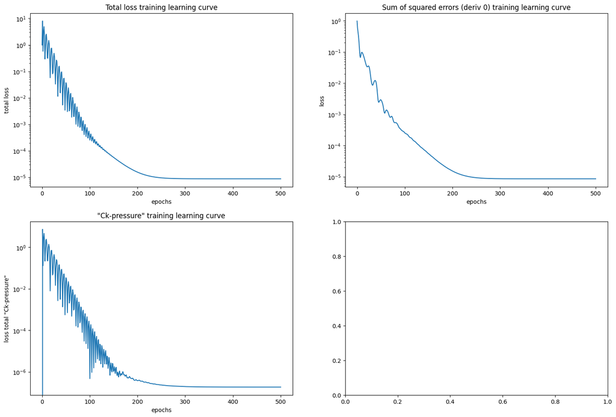

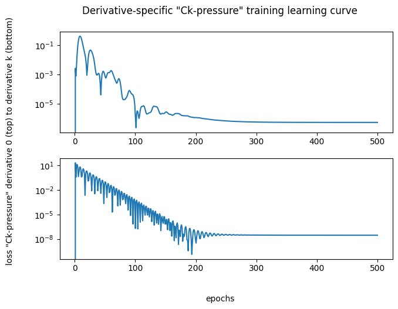

```python
fig, axes = plt.subplots(2, 2, figsize=(18, 12))

# You can now customize each axis as needed
plot.plot_loss(spline_shifted_chebyshev, 'total', ax=axes[0][0])
plot.plot_loss(spline_shifted_chebyshev, 'approx', ax=axes[0][1])
plot.plot_loss(spline_shifted_chebyshev, 'ck-D', ax=axes[1][0])
plot.plot_loss(spline_shifted_chebyshev, 'ck-d', ax=axes[1][1])

# Show the plot
plt.show()
```

### Discussion

Power Basis and Shifted Chebyshev Polynomials show the best results in the combined L2 + Ck-Loss Setting.

### Degree 5 polynomials, C^2-continuity

```python
lambd = 0.5
ck=2
degree=5
```

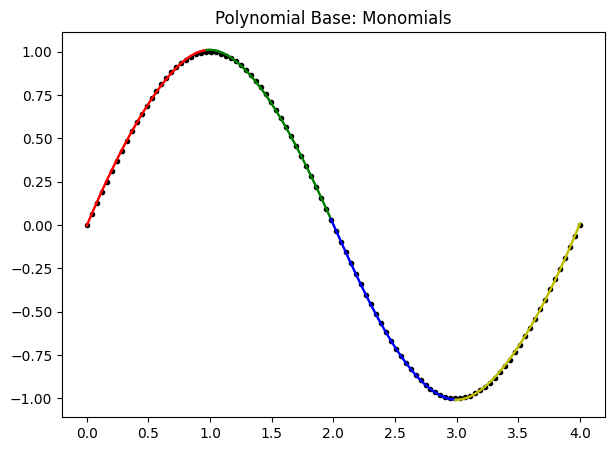

```python
spline_monomial = model.Spline(polydegree=degree, polynum=n_segments, ck=ck)
spline_monomial.continuity = False
opt_sgd = keras.optimizers.SGD(learning_rate=learning_rate, momentum=0.95, nesterov=True)
opt_ams = keras.optimizers.Adam(learning_rate=learning_rate, amsgrad=True)

spline_monomial.fit(data_x, data_y, optimizer=opt_ams, n_epochs=epochs, factor_approximation_quality=lambd,
factor_ck_pressure=1-lambd, initialize_l2fit=False)

plot.plot_spline(spline_monomial, title='Polynomial Base: Monomials')
```

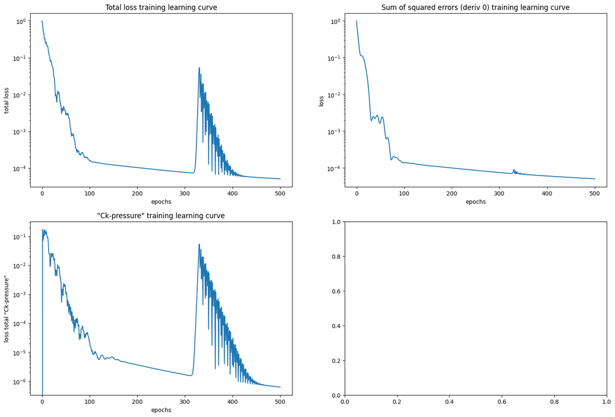

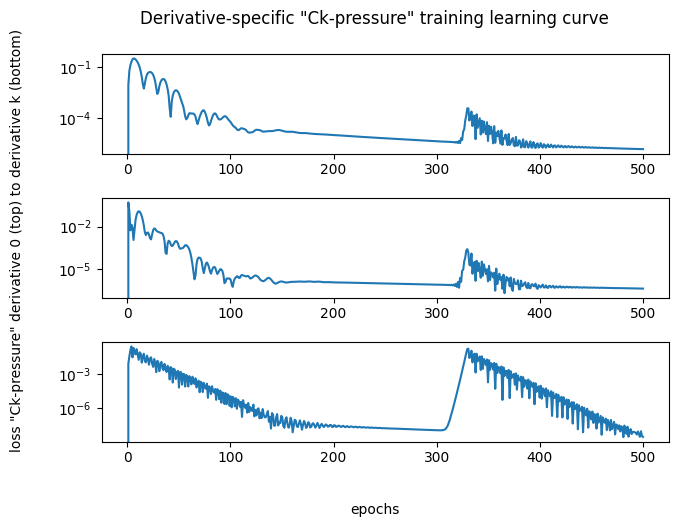

```python
fig, axes = plt.subplots(2, 2, figsize=(18, 12))

# You can now customize each axis as needed
plot.plot_loss(spline_monomial, 'total', ax=axes[0][0])
plot.plot_loss(spline_monomial, 'approx', ax=axes[0][1])
plot.plot_loss(spline_monomial, 'ck-D', ax=axes[1][0])
plot.plot_loss(spline_monomial, 'ck-d', ax=axes[1][1])

# Show the plot
plt.show()
```

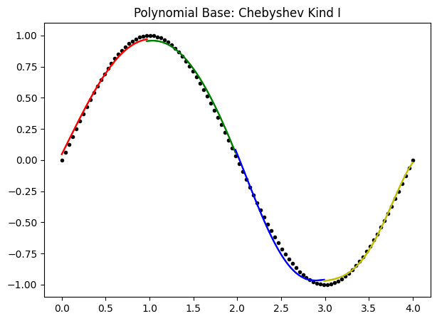

```python
spline_chebyshev = model.Spline(polydegree=degree, polynum=n_segments, ck=ck, basis='chebyshev', shift_polynomial_centers='boundary')
spline_chebyshev.continuity = False
opt_sgd = keras.optimizers.SGD(learning_rate=learning_rate, momentum=0.95, nesterov=True)
opt_ams = keras.optimizers.Adam(learning_rate=learning_rate, amsgrad=True)

spline_chebyshev.fit(data_x, data_y, optimizer=opt_ams, n_epochs=epochs, factor_approximation_quality=lambd,
factor_ck_pressure=1-lambd, initialize_l2fit=False)

plot.plot_spline(spline_chebyshev, title='Polynomial Base: Chebyshev Kind I')
```